# Spatial Analysis of Basketball Shots in R

## Why [`R`](https://www.r-project.org/about.html)?

Reproducibility is the main advantage of using `R` over a standard spatial analysis software such as ArcGIS. `R` uses scripts which means that analyses can be shared and reproduced easily. The programming language was built for and by statisticians who decided to keep it an open source. As a result, many packages have emerged to extend its functionality to specific niches. The [RStudio](https://www.rstudio.com/) IDE makes `R` more approachable. This series of articles are produced using [R Mardown](https://rmarkdown.rstudio.com/) and [Bookdown](https://bookdown.org/) which are integrated within RStudio.

## Why the [`tidyverse`](https://www.tidyverse.org/) package?

> “The `tidyverse` is an opinionated collection of R packages designed for data science. All packages share an underlying design philosophy, grammar, and data structures.”

Two key characteristics of the `tidyverse` are [tidy data](https://r4ds.had.co.nz/tidy-data.html) and [piping](https://style.tidyverse.org/pipes.html).

There are three interrelated rules which make a dataset tidy:

1. Each variable must have its own column.
2. Each observation must have its own row.
3. Each value must have its own cell.

The analysis described in this series of articles makes use of tidy data, piping, and attempts to follow this coding [style guide](http://adv-r.had.co.nz/Style.html) as much as possible.

## Why the [`sf`](https://r-spatial.github.io/sf/) package?

It is possible to create advanced shot charts using base `R` or with the `tidyverse`. In fact, the analysis and shiny app were heavily influenced by Todd W. Schneider’s [BallR Shiny app](https://github.com/toddwschneider/ballr). The [simple features](https://r-spatial.github.io/sf/) (`sf`) package was built to modernize the widely used [`sp`](https://cran.r-project.org/web/packages/sp/vignettes/intro_sp.pdf) package. Part of this modernization was to treat spatial objects as data frames so it would be compatible with the tidyverse.

Spatial data often requires special treatment. Observations may not be independent of their neighbours. In fact, [Tobler’s First Law of Geography](https://en.wikipedia.org/wiki/Tobler%27s_first_law_of_geography) states that “everything is related to everything else, but near things are more related than distant things.” Creating maps and polygons using non-spatial tools such as the tidyverse can be laborious and computationally inefficient. Using [tools](https://github.com/rstudio/cheatsheets/blob/master/sf.pdf) from the `sf` package makes it much more efficient to create and analyze spatial data. Moreover, an argument can be made that nearly all data are spatio-temporal in nature since they are collected *somewhere* at some *time*. At the time of this writing, spatial data have never been easier to collect. Yet, the online tutorial community has not yet caught up to the tsunami of coordinate data.

# Track and Export Basketball Shot Coordinates

Shot coordinates can be tracked manually using pen paper. One could then estimate the $(x, ~y)$ coordinates of each point by first choosing a reference frame for the basketball court. Let’s consider a FIBA basketball court (exact dimensions can be found [here](https://www.fiba.basketball/documents/official-basketball-rules/2020.pdf)). We can focus on the half-court for now and set the origin of our two-dimensional coordinate system at the bottom left corner of the image below.

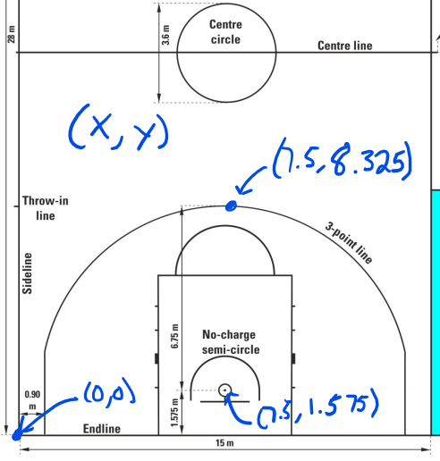

Cropped and labelled FIBA basketball court

Once we’ve picked a coordinate system, then we could visually estimate the $(x, ~y)$ coordinates of each shot that was tracked on paper. Of course, this is not ideal. I built this [Desmos](https://www.desmos.com/calculator/pcsvcpcwy8) file in the early days to manually estimate the shot coordinates.

This is where the [Easy Stats](https://www.easystatsapp.com/) iOS application comes in. You can watch this [video tutorial](https://youtu.be/A4f4gioAnFg) to see how one can easily track and export more precise shot coordinates.